# Mixed Models Assignment

T. G. Walker

9/28/2021

For part 1 I used a Data set that took 3 Pallid bats and looked at how different sound treatments affected their ability to echolocate and source prey. They were each placed in a box and exposed to 1 of three sound treatments emitting from 1 of multiple speakers in the box, multiple times and then there search time was recorded in each to view how each sound affected them. These sounds were either Ambient (Control), Overlapping, and Non-Overlapping.

The overlapping and non over lapping refers to the decibels emitted and whether it overlapped with the sound of common prey insects calling and the non overlapping were sounds that were of higher frequency then said insects.

Success and search time ended when the bats landed at the correct speaker emitting noise.

```r
lmeModel<-lmer(Search_time ~ Treatment*Night + (1|Bat), data=bat_data)
anova(lmeModel)
```

```
## Type III Analysis of Variance Table with Satterthwaite's method
##                 Sum Sq Mean Sq NumDF  DenDF F value    Pr(>F)
## Treatment       4688.1 2344.06     2 358.24 30.6348 5.226e-13 ***
## Night            337.0  336.99     1 358.13  4.4041  0.036552 *
## Treatment:Night  714.3  357.15     2 358.17  4.6676  0.009974 **
## ---
## Signif. codes:  0 '***' 0.001 '**' 0.01 '*' 0.05 '.' 0.1 ' ' 1
```

So here we see that both Night and Sound Treatment both have a significant effect on the bats search time.

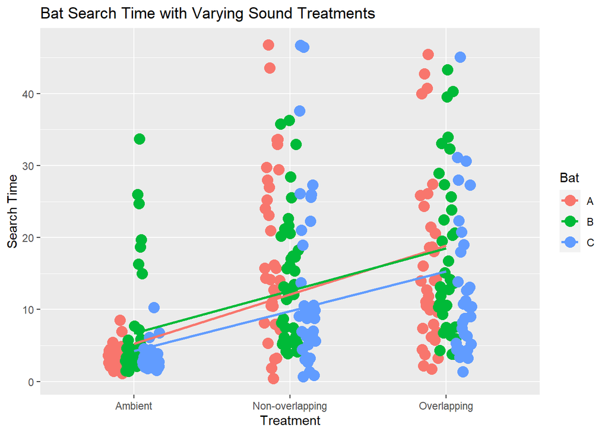

```r
Bat_sound.plot1<- ggplot(bat_data, aes(x=Treatment, y=Search_time, group=Bat, color=Bat)) +
  geom_point(size=4, position = position_dodge2(width=.33, preserve = "total")) +
  #geom_line() +
  geom_smooth(method = "lm", se = FALSE) +
  labs(title="Bat Search Time with Varying Sound Treatments", x= "Treatment", y = "Search Time")
Bat_sound.plot1
```

```r
search_means <- bat_data %>%
  group_by(Treatment) %>%
  summarise(mean_search_time=mean(Search_time),
            se_search=sd(Search_time)/sqrt(n()))
search_means
```

```
## # A tibble: 3 x 3
##   Treatment       mean_search_time se_search
##   <chr>                      <dbl>     <dbl>
## 1 Ambient                     4.21     0.339
## 2 Non-overlapping            15.0      1.09
## 3 Overlapping                15.8      1.11
```

```r
mixed_bat_searchtime <- lmer(Search_time~(Treatment*Bat)+(1|Bat), data = bat_data)
anova(mixed_bat_searchtime)
```

```
## Type III Analysis of Variance Table with Satterthwaite's method
##                Sum Sq Mean Sq NumDF DenDF F value Pr(>F)
## Treatment     11202.2  5601.1     2   356 72.2997 <2e-16 ***
## Bat             196.4    98.2     2     0  1.2676  1.000
## Treatment:Bat   495.6   123.9     4   356  1.5992  0.174
## ---
## Signif. codes:  0 '***' 0.001 '**' 0.01 '*' 0.05 '.' 0.1 ' ' 1
```

Notice the Degrees of freedom match up with 3 treatments and three bats and that treatments definitely have a significant effect.

Next Let’s look at the summary

```r
summary(mixed_bat_searchtime)
```

```
## Linear mixed model fit by REML. t-tests use Satterthwaite's method [
## lmerModLmerTest]
## Formula: Search_time ~ (Treatment * Bat) + (1 | Bat)
##    Data: bat_data
##
## REML criterion at convergence: 2592
##
## Scaled residuals:
##     Min      1Q  Median      3Q     Max
## -1.9825 -0.5250 -0.1061  0.1522  3.8079
##
## Random effects:
##  Groups   Name        Variance Std.Dev.
##  Bat      (Intercept)  1.196   1.093
##  Residual             77.470   8.802
## Number of obs: 365, groups:  Bat, 3
##
## Fixed effects:
##                                 Estimate Std. Error         df t value Pr(>|t|)
## (Intercept)                    3.444e+00  1.630e+00  9.546e-09   2.112   1.0000
## TreatmentNon-overlapping       1.445e+01  1.952e+00  3.560e+02   7.402 9.79e-13
## TreatmentOverlapping           1.270e+01  1.917e+00  3.560e+02   6.625 1.29e-10
## BatB                           2.670e+00  2.311e+00  9.647e-09   1.155   1.0000
## BatC                          -3.230e-01  2.305e+00  9.546e-09  -0.140   1.0000
## TreatmentNon-overlapping:BatB -6.346e+00  2.709e+00  3.560e+02  -2.343   0.0197
## TreatmentOverlapping:BatB     -1.188e+00  2.716e+00  3.560e+02  -0.438   0.6620
## TreatmentNon-overlapping:BatC -4.363e+00  2.736e+00  3.560e+02  -1.595   0.1116
## TreatmentOverlapping:BatC     -2.420e+00  2.763e+00  3.560e+02  -0.876   0.3818
##
## (Intercept)
## TreatmentNon-overlapping      ***
## TreatmentOverlapping          ***
## BatB
## BatC
## TreatmentNon-overlapping:BatB *
## TreatmentOverlapping:BatB
## TreatmentNon-overlapping:BatC
## TreatmentOverlapping:BatC
## ---
## Signif. codes:  0 '***' 0.001 '**' 0.01 '*' 0.05 '.' 0.1 ' ' 1
##
## Correlation of Fixed Effects:
##             (Intr) TrtmN- TrtmnO BatB   BatC   TN-:BB TrO:BB TN-:BC
## TrtmntNn-vr -0.459
## TrtmntOvrlp -0.468  0.391
## BatB        -0.705  0.324  0.330
## BatC        -0.707  0.325  0.331  0.499
## TrtmntN-:BB  0.331 -0.721 -0.281 -0.471 -0.234
## TrtmntOv:BB  0.330 -0.276 -0.706 -0.470 -0.233  0.401
## TrtmntN-:BC  0.328 -0.713 -0.279 -0.231 -0.464  0.514  0.197
## TrtmntOv:BC  0.324 -0.271 -0.694 -0.229 -0.459  0.195  0.490  0.387
## optimizer (nloptwrap) convergence code: 0 (OK)
## unable to evaluate scaled gradient
##  Hessian is numerically singular: parameters are not uniquely determined
```

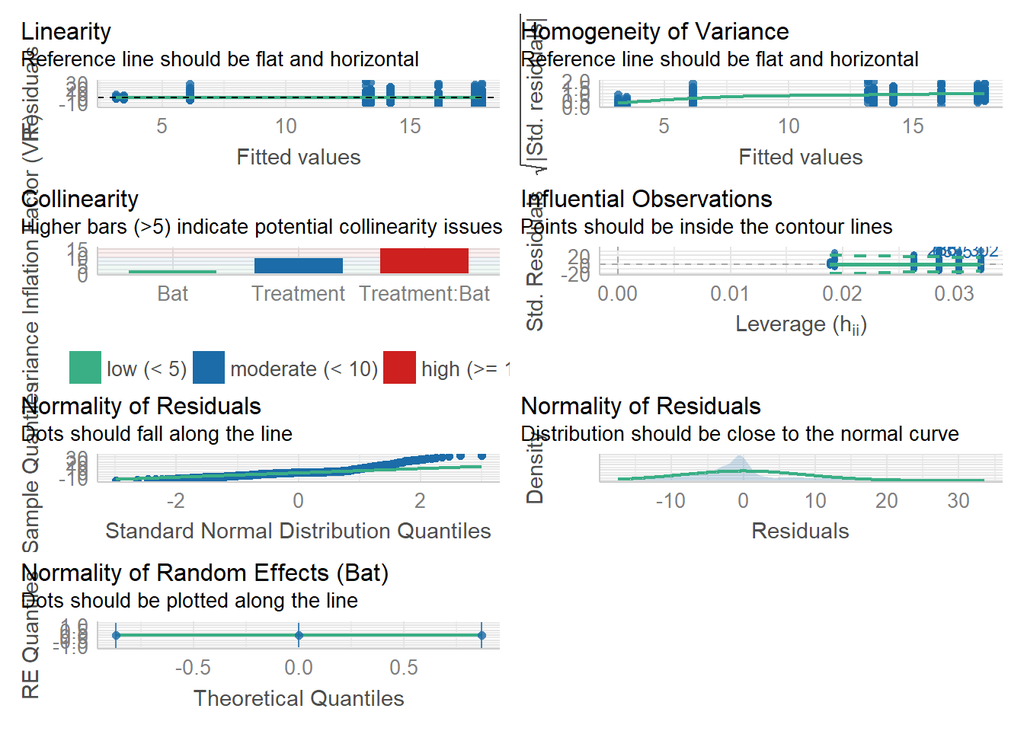

```r
performance::check_model(mixed_bat_searchtime)
```

Next we calculate Model adjusted means

```r
mixed_bat_searchtime_emm <- emmeans(mixed_bat_searchtime, "Treatment")
```

```
## NOTE: Results may be misleading due to involvement in interactions
```

```r
mixed_bat_searchtime_emm
```

```
##  Treatment       emmean    SE   df lower.CL upper.CL
##  Ambient           4.23 0.943 1170     2.38     6.08
##  Non-overlapping  15.10 1.064  848    13.01    17.19
##  Overlapping      15.72 1.081  820    13.60    17.84
##
## Results are averaged over the levels of: Bat
## Degrees-of-freedom method: kenward-roger
## Confidence level used: 0.95
```

```r
emmeans(mixed_bat_searchtime, "Bat")
```

```
## NOTE: Results may be misleading due to involvement in interactions
```

```
##  Bat emmean   SE   df lower.CL upper.CL
##  A    12.49 1.37 2765     9.81     15.2
##  B    12.65 1.35 2941    10.00     15.3
##  C     9.91 1.37 2679     7.22     12.6
##
## Results are averaged over the levels of: Treatment
## Degrees-of-freedom method: kenward-roger
## Confidence level used: 0.95
```

```r
emmeans(mixed_bat_searchtime, "Treatment","Bat")
```

```
## Bat = A:
##  Treatment       emmean   SE   df lower.CL upper.CL
##  Ambient           3.44 1.63 1177   0.2452     6.64
##  Non-overlapping  17.89 1.88  811  14.1948    21.58
##  Overlapping      16.14 1.85  845  12.5197    19.77
##
## Bat = B:
##  Treatment       emmean   SE   df lower.CL upper.CL
##  Ambient           6.11 1.64 1157   2.8982     9.33
##  Non-overlapping  14.21 1.80  896  10.6838    17.74
##  Overlapping      17.63 1.85  845  14.0011    21.25
##
## Bat = C:
##  Treatment       emmean   SE   df lower.CL upper.CL
##  Ambient           3.12 1.63 1177  -0.0778     6.32
##  Non-overlapping  13.20 1.85  845   9.5797    16.83
##  Overlapping      13.40 1.92  778   9.6277    17.17
##
## Degrees-of-freedom method: kenward-roger
## Confidence level used: 0.95
```

```r
emmeans(mixed_bat_searchtime, "Bat", "Treatment")
```

```
## Treatment = Ambient:
##  Bat emmean   SE   df lower.CL upper.CL
##  A     3.44 1.63 1177   0.2452     6.64
##  B     6.11 1.64 1157   2.8982     9.33
##  C     3.12 1.63 1177  -0.0778     6.32
##
## Treatment = Non-overlapping:
##  Bat emmean   SE   df lower.CL upper.CL
##  A    17.89 1.88  811  14.1948    21.58
##  B    14.21 1.80  896  10.6838    17.74
##  C    13.20 1.85  845   9.5797    16.83
##
## Treatment = Overlapping:
##  Bat emmean   SE   df lower.CL upper.CL
##  A    16.14 1.85  845  12.5197    19.77
##  B    17.63 1.85  845  14.0011    21.25
##  C    13.40 1.92  778   9.6277    17.17
##
## Degrees-of-freedom method: kenward-roger
## Confidence level used: 0.95
```

Raw means vs. Model Adjusted Means

```r
bat_data_emm <- as.data.frame(mixed_bat_searchtime_emm)
bat_data_emm
```

```
##         Treatment    emmean        SE        df  lower.CL  upper.CL
## 1         Ambient  4.225871 0.9428318 1169.9325  2.376041  6.075701
## 2 Non-overlapping 15.102277 1.0638964  848.1687 13.014099 17.190456
## 3     Overlapping 15.723275 1.0807961  820.2680 13.601823 17.844727
```

```r
search_means
```

```
## # A tibble: 3 x 3
##   Treatment       mean_search_time se_search
##   <chr>                      <dbl>     <dbl>
## 1 Ambient                     4.21     0.339
## 2 Non-overlapping            15.0      1.09
## 3 Overlapping                15.8      1.11
```

Here is the plot of raw means vs adjusted means for evaluation

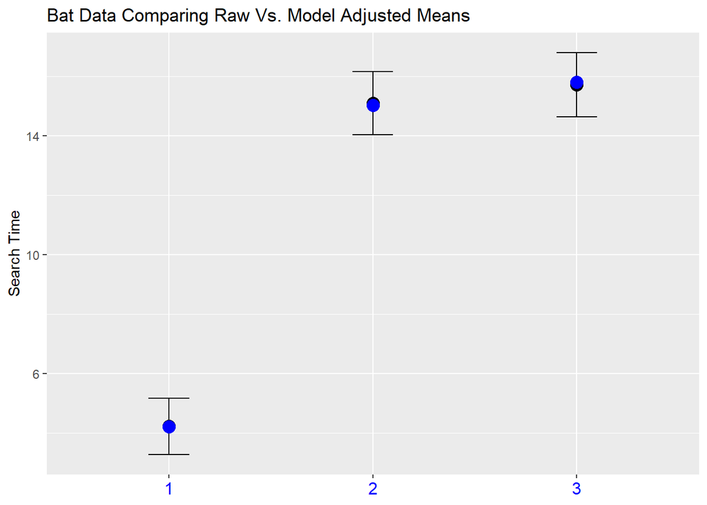

```r
Bat_data_plot2<- ggplot(bat_data_emm, aes(x=Treatment, y=emmean)) +
  geom_point(size=4) +
  geom_errorbar(aes(ymin=emmean-SE, ymax=emmean+SE), width=.2) +
  labs(title="Bat Data Comparing Raw Vs. Model Adjusted Means", x= NULL, y = "Search Time") +
  geom_point(data=search_means, size=4, x=search_means$Treatment, y=search_means$mean_search_time, color="blue") +
  theme(axis.text.x = ggtext::element_markdown(color = "blue", size = 12)) +
  scale_x_discrete(name = NULL, labels = labels)
Bat_data_plot2
```

Next are the pairs camparisons

```r
pairs(emmeans(mixed_bat_searchtime, "Treatment"))
```

```
## NOTE: Results may be misleading due to involvement in interactions
```

```
##  contrast                        estimate   SE  df t.ratio p.value
##  Ambient - (Non-overlapping)      -10.876 1.11 356  -9.832  <.0001
##  Ambient - Overlapping            -11.497 1.12 356 -10.243  <.0001
##  (Non-overlapping) - Overlapping   -0.621 1.23 356  -0.507  0.8682
##
## Results are averaged over the levels of: Bat
## Degrees-of-freedom method: kenward-roger
## P value adjustment: tukey method for comparing a family of 3 estimates
```

```r
 pairs(emmeans(mixed_bat_searchtime, "Bat"))
```

```
## NOTE: Results may be misleading due to involvement in interactions
```

```
##  contrast estimate   SE   df t.ratio p.value
##  A - B      -0.158 1.92 2850  -0.082  0.9963
##  A - C       2.584 1.94 2721   1.335  0.3759
##  B - C       2.742 1.93 2803   1.423  0.3293
##
## Results are averaged over the levels of: Treatment
## Degrees-of-freedom method: kenward-roger
## P value adjustment: tukey method for comparing a family of 3 estimates
```

No Reason for the next table but just for comparison

```r
emmeans(mixed_bat_searchtime, specs = pairwise ~ Treatment:Bat)
```

```
## $emmeans
##  Treatment       Bat emmean   SE   df lower.CL upper.CL
##  Ambient         A     3.44 1.63 1177   0.2452     6.64
##  Non-overlapping A    17.89 1.88  811  14.1948    21.58
##  Overlapping     A    16.14 1.85  845  12.5197    19.77
##  Ambient         B     6.11 1.64 1157   2.8982     9.33
##  Non-overlapping B    14.21 1.80  896  10.6838    17.74
##  Overlapping     B    17.63 1.85  845  14.0011    21.25
##  Ambient         C     3.12 1.63 1177  -0.0778     6.32
##  Non-overlapping C    13.20 1.85  845   9.5797    16.83
##  Overlapping     C    13.40 1.92  778   9.6277    17.17
##
## Degrees-of-freedom method: kenward-roger
## Confidence level used: 0.95
##
## $contrasts
##  contrast                                  estimate   SE   df t.ratio p.value
##  Ambient A - (Non-overlapping A)            -14.446 1.95  356  -7.402  <.0001
##  Ambient A - Overlapping A                  -12.700 1.92  356  -6.625  <.0001
##  Ambient A - Ambient B                       -2.670 2.31 1167  -1.155  0.9654
##  Ambient A - (Non-overlapping B)            -10.770 2.43 1009  -4.437  0.0003
##  Ambient A - Overlapping B                  -14.182 2.46  970  -5.758  <.0001
##  Ambient A - Ambient C                        0.323 2.31 1177   0.140  1.0000
##  Ambient A - (Non-overlapping C)             -9.760 2.46  970  -3.963  0.0026
##  Ambient A - Overlapping C                   -9.957 2.52  916  -3.951  0.0027
##  (Non-overlapping A) - Overlapping A          1.746 2.14  356   0.818  0.9963
##  (Non-overlapping A) - Ambient B             11.776 2.50  938   4.718  0.0001
##  (Non-overlapping A) - (Non-overlapping B)    3.676 2.60  850   1.412  0.8933
##  (Non-overlapping A) - Overlapping B          0.265 2.64  827   0.100  1.0000
##  (Non-overlapping A) - Ambient C             14.769 2.49  943   5.931  <.0001
##  (Non-overlapping A) - (Non-overlapping C)    4.686 2.64  827   1.777  0.6974
##  (Non-overlapping A) - Overlapping C          4.489 2.69  794   1.668  0.7657
##  Overlapping A - Ambient B                   10.030 2.47  964   4.063  0.0017
##  Overlapping A - (Non-overlapping B)          1.930 2.58  869   0.749  0.9980
##  Overlapping A - Overlapping B               -1.481 2.61  845  -0.567  0.9997
##  Overlapping A - Ambient C                   13.023 2.46  970   5.287  <.0001
##  Overlapping A - (Non-overlapping C)          2.940 2.61  845   1.126  0.9703
##  Overlapping A - Overlapping C                2.743 2.67  809   1.029  0.9830
##  Ambient B - (Non-overlapping B)             -8.100 1.88  356  -4.312  0.0007
##  Ambient B - Overlapping B                  -11.512 1.92  356  -5.982  <.0001
##  Ambient B - Ambient C                        2.993 2.31 1167   1.295  0.9330
##  Ambient B - (Non-overlapping C)             -7.090 2.47  964  -2.872  0.0968
##  Ambient B - Overlapping C                   -7.288 2.53  911  -2.885  0.0936
##  (Non-overlapping B) - Overlapping B         -3.412 2.06  356  -1.655  0.7736
##  (Non-overlapping B) - Ambient C             11.093 2.43 1009   4.570  0.0002
##  (Non-overlapping B) - (Non-overlapping C)    1.010 2.58  869   0.392  1.0000
##  (Non-overlapping B) - Overlapping C          0.812 2.63  830   0.309  1.0000
##  Overlapping B - Ambient C                   14.505 2.46  970   5.889  <.0001
##  Overlapping B - (Non-overlapping C)          4.421 2.61  845   1.693  0.7507
##  Overlapping B - Overlapping C                4.224 2.67  809   1.585  0.8131
##  Ambient C - (Non-overlapping C)            -10.083 1.92  356  -5.260  <.0001
##  Ambient C - Overlapping C                  -10.280 1.99  356  -5.166  <.0001
##  (Non-overlapping C) - Overlapping C         -0.197 2.17  356  -0.091  1.0000
##
## Degrees-of-freedom method: kenward-roger
## P value adjustment: tukey method for comparing a family of 9 estimates
```

For Part 2: Nested Design I fabricated some data looking at male alligator weights by different ‘beaches’ they were collected from that act as a ‘cage’. I chose this option because non dominant male alligators actually get pushed out to beach areas in coastal regions in the wild by dominant males in better habitat types mostly swamps located inland. So I decided to see if any of these beach areas that I created would actually show any relationships to alligator weights (also made up).

There are thirteen individuals spread across 3 beaches with weight measurements that were taken three separate times.

Here is the plot of each gator

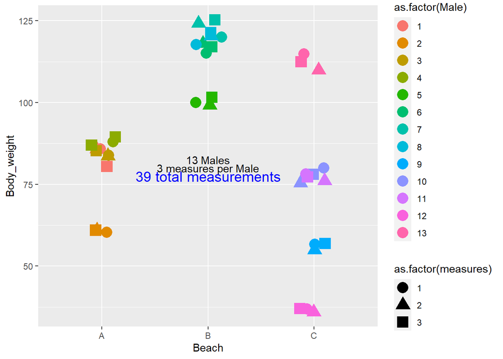

```r
Alligator.plot<-ggplot(Alligator_weight, aes(Beach, Body_weight, colour = as.factor(Male), shape=as.factor(measures))) +
  geom_jitter(width =0.15, size=5) +
  annotate("text", x = 2, y = 82.5, label = "13 Males") +
  annotate("text", x = 2, y = 80, label = "3 measures per Male") +
  annotate("text", x = 2, y = 77.5, label = "39 total measurements", size=5, color="blue")

Alligator.plot
```

```r
alligators.1 <- lmer(Body_weight ~ Beach + (1|Beach/Male), data = Alligator_weight )
summary(alligators.1)
```

```
## Linear mixed model fit by REML. t-tests use Satterthwaite's method [
## lmerModLmerTest]
## Formula: Body_weight ~ Beach + (1 | Beach/Male)
##    Data: Alligator_weight
##
## REML criterion at convergence: 210.9
##
## Scaled residuals:
##     Min      1Q  Median      3Q     Max
## -2.0067 -0.4982  0.1028  0.5973  1.4776
##
## Random effects:
##  Groups     Name        Variance  Std.Dev.
##  Male:Beach (Intercept) 3.969e+02 19.92246
##  Beach      (Intercept) 2.264e-03  0.04758
##  Residual               3.196e+00  1.78771
## Number of obs: 39, groups:  Male:Beach, 13; Beach, 3
##
## Fixed effects:
##             Estimate Std. Error      df t value Pr(>|t|)
## (Intercept)  79.3083     9.9747  0.7426   7.951    0.133
## BeachB       35.6917    14.1064  0.7426   2.530    0.304
## BeachC       -7.2550    13.3825  0.6102  -0.542    0.723
##
## Correlation of Fixed Effects:
##        (Intr) BeachB
## BeachB -0.707
## BeachC -0.745  0.527
## optimizer (nloptwrap) convergence code: 0 (OK)
## unable to evaluate scaled gradient
##  Hessian is numerically singular: parameters are not uniquely determined
```

```r
anova(alligators.1)
```

```
## Type III Analysis of Variance Table with Satterthwaite's method
##       Sum Sq Mean Sq NumDF DenDF F value Pr(>F)
## Beach 36.027  18.014     2     2  5.6365 0.1507
```

We are Interested in each beach and because we had unbalanced sampling

```r
alligators.2 <- lmer(Body_weight ~ (1|Beach/Male), data = Alligator_weight)
summary(alligators.2)
```

```
## Linear mixed model fit by REML. t-tests use Satterthwaite's method [
## lmerModLmerTest]
## Formula: Body_weight ~ (1 | Beach/Male)
##    Data: Alligator_weight
##
## REML criterion at convergence: 230.2
##
## Scaled residuals:
##     Min      1Q  Median      3Q     Max
## -2.0093 -0.5020  0.1002  0.5996  1.4737
##
## Random effects:
##  Groups     Name        Variance Std.Dev.
##  Male:Beach (Intercept) 397.101  19.927
##  Beach      (Intercept) 433.040  20.810
##  Residual                 3.196   1.788
## Number of obs: 39, groups:  Male:Beach, 13; Beach, 3
##
## Fixed effects:
##             Estimate Std. Error     df t value Pr(>|t|)
## (Intercept)   88.573     13.239  1.988   6.691   0.0219 *
## ---
## Signif. codes:  0 '***' 0.001 '**' 0.01 '*' 0.05 '.' 0.1 ' ' 1
```

```r
anova(alligators.2)
```

```
## Type III Analysis of Variance Table with Satterthwaite's method
##      Sum Sq Mean Sq NumDF DenDF F value Pr(>F)
```

```r
anova(alligators.2,alligators.1, test = "Chisq")
```

```
## refitting model(s) with ML (instead of REML)
```

```
## Data: Alligator_weight
## Models:
## alligators.2: Body_weight ~ (1 | Beach/Male)
## alligators.1: Body_weight ~ Beach + (1 | Beach/Male)
##              npar    AIC    BIC  logLik deviance  Chisq Df Pr(>Chisq)
## alligators.2    4 245.00 251.65 -118.50   237.00
## alligators.1    6 241.58 251.56 -114.79   229.58 7.4156  2    0.02453 *
## ---
## Signif. codes:  0 '***' 0.001 '**' 0.01 '*' 0.05 '.' 0.1 ' ' 1
```